# Fc-OPG PK/PD in healthy post-menopausal women

Metrum Research Group, LLC

# Packages

```r
library(mrgsolve)
library(dplyr)
library(magrittr)
library(parallel)
library(ggplot2)
```

## Question

- What is the median change from baseline 14 days after 3 mg/kg SC dose?
- What is the probability that median CFB is greater than 40%?

# OPG model

```r
mod <- mread("opg", "model")

mod
```

```
.
.
. -------- mrgsolve model object (unix) --------
.   Project: /Users/kyleb/git...rgsolve/model
.   source:        opg.cpp
.   shared object: opg-so-9e0e339fa3eb
.
.   Time:          start: 0 end: 24 delta: 1
.   >              add: <none>
.   >              tscale: 1
.
.   Compartments:  SC CENT P1 P2 NTX [5]
.   Parameters:    IV TVCL TVVC TVVP1 TVVP2 TVQ1
.   >              TVQ2 TVKA TVVMAX TVKM TVFSC TVKSYN
.   >              TVKDEG TVIC50 [14]
.   Omega:         7x7,3x3
.   Sigma:         2x2,2x2
.
.   Solver:        atol: 1e-08 rtol: 1e-08
.   >              maxsteps: 2000 hmin: 0 hmax: 0
```

Checkout the random effects structure

```r
revar(mod)
```

```
. $omega
. $...
.          [,1]   [,2]   [,3]   [,4]   [,5]   [,6]  [,7]
. ECL:   0.0391 0.0000 0.0000 0.0000 0.0000 0.0000 0.000
. EVC:   0.0000 0.0102 0.0000 0.0000 0.0000 0.0000 0.000
. EVP1:  0.0000 0.0000 0.0144 0.0000 0.0000 0.0000 0.000
. EVP2:  0.0000 0.0000 0.0000 0.0333 0.0000 0.0000 0.000
. EQ1:   0.0000 0.0000 0.0000 0.0000 0.0379 0.0000 0.000
. EKA:   0.0000 0.0000 0.0000 0.0000 0.0000 0.0457 0.000
. EFSC:  0.0000 0.0000 0.0000 0.0000 0.0000 0.0000 0.263
.
. $...
.           [,1]   [,2] [,3]
. EKSYN:  0.2810 0.0867 0.00
. EKDEG:  0.0867 0.0325 0.00
. EIC50:  0.0000 0.0000 1.18
.
.
. $sigma
. $...
.           [,1]  [,2]
. ADDIV:  0.0193 0.000
. ADDSC:  0.0000 0.733
.
. $...
.            [,1] [,2]
. PDPROP:  0.0407  0.0
. PDADD:   0.0000 20.7
```

```r
mod %<>% mrgsolve:::collapse_omega()
mod %<>% mrgsolve:::collapse_sigma()
```

We can render this in to an `Rmarkdown` document

```r
mrgsolve:::render(mod)
```

# Load the simulated posterior

```r
post <- readRDS("data/opgpost.RDS") %>% sample_n(1000)

post %>% head
```

```
.      TVCL TVVC  TVP1  TVP2  TVQ1  TVQ2    TVKA TVVMAX  TVKM  TVFSC TVKSYN
. 878 166.7 2772 404.2 352.1 15.31 2.877 0.01212  11890 6.155 0.0719 0.8655
. 621 166.0 2852 368.8 217.0 14.65 3.320 0.01355  13150 7.556 0.0719 0.8769
. 548 173.1 2780 428.8 241.9 16.23 3.135 0.01299  16910 7.737 0.0719 0.9301
. 83  174.0 2765 432.8 213.8 16.14 3.320 0.01410  11990 6.530 0.0719 0.8450
. 99  171.1 2812 429.1 263.3 13.32 2.937 0.01332  13420 7.618 0.0719 0.8654
. 674 164.9 2817 516.7 272.5 13.83 2.830 0.01289  12090 6.312 0.0719 0.7856
.      TVKDEG TVIC50 OMEGA11  OMEGA21 OMEGA22   OMEGA31   OMEGA32 OMEGA33
. 878 0.02223  5.094 0.04134 0.002897 0.01235 -0.001575  0.001971 0.01837
. 621 0.02174  3.966 0.05612 0.002774 0.01360 -0.000626  0.000848 0.01447
. 548 0.02020  5.454 0.05420 0.002533 0.01179  0.001944 -0.002160 0.01711
. 83  0.02122  6.173 0.03798 0.003317 0.01567  0.001675  0.000975 0.01429
. 99  0.01971  4.775 0.05667 0.000664 0.01415 -0.006782  0.003748 0.01523
. 674 0.01890  3.144 0.03438 0.000810 0.01217 -0.003092  0.001139 0.01573
.       OMEGA41   OMEGA42   OMEGA43 OMEGA44   OMEGA51   OMEGA52   OMEGA53
. 878 -0.002087  0.000960  0.000859 0.02898 -0.001528  0.001353 -0.003398
. 621  0.002021  0.002314 -0.000911 0.04886  0.009640 -0.001983 -0.002152
. 548  0.002796 -0.000459  0.004124 0.03380  0.001493  0.000068 -0.001181
. 83   0.000748  0.001178 -0.001434 0.03124 -0.007083 -0.005991  0.000307
. 99  -0.000156 -0.000775 -0.002473 0.03950 -0.003633 -0.001848  0.002458
. 674 -0.002178 -0.000470 -0.000894 0.03237 -0.005967  0.000839  0.002864
.       OMEGA54 OMEGA55   OMEGA61   OMEGA62   OMEGA63   OMEGA64   OMEGA65
. 878 -0.004751 0.04113  0.000575 -0.000572  0.004095 -0.005038  0.000105
. 621 -0.002584 0.03132 -0.012110  0.004682  0.004408  0.003532 -0.006657
. 548  0.007963 0.04904  0.003438 -0.003170 -0.001271  0.008071  0.010980
. 83  -0.000393 0.04635  0.002810  0.001873  0.000156  0.002839  0.003014
. 99   0.003165 0.05090 -0.010570 -0.009859 -0.001541 -0.006745 -0.002620
. 674 -0.004656 0.04310  0.000050  0.001524 -0.000313 -0.004688  0.000265
.     OMEGA66   OMEGA71   OMEGA72   OMEGA73   OMEGA74   OMEGA75   OMEGA76
. 878 0.04978 -0.017420 -0.001506  0.011780 -0.001595  0.002112  0.002040
. 621 0.05715  0.006032 -0.002070 -0.008303 -0.000966 -0.007049 -0.005394
. 548 0.06440  0.030470 -0.001104 -0.000216  0.016600  0.030040  0.013210
. 83  0.04445  0.008379  0.004383 -0.009583  0.003713 -0.010330  0.003895
. 99  0.07933 -0.008878 -0.015640 -0.006263 -0.005468 -0.000792 -0.014340
. 674 0.04516 -0.000106 -0.001458 -0.001850  0.008494 -0.016540 -0.013370
.     OMEGA77   OMEGA81   OMEGA82   OMEGA83   OMEGA84   OMEGA85   OMEGA86
. 878  0.2728  0.001766  0.006035 -0.006726 -0.004420  0.021140 -0.012550
. 621  0.2588  0.015240 -0.002388  0.001660 -0.027260  0.017000 -0.011060
. 548  0.3032  0.006291 -0.004632 -0.000677  0.014860  0.010720  0.016870
. 83   0.2368 -0.018240  0.004004 -0.002486  0.007104 -0.017230 -0.002740
```

[output cut: 22 more lines]

```
. 674  0.018530 -0.000139  0.01905 -0.079660  0.01424  0.009970     1.291
.     SIGMA11   SIGMA21 SIGMA22   SIGMA31   SIGMA32 SIGMA33   SIGMA41
. 878 0.02004 -0.000482  0.6664 -0.000873  0.006414 0.03921 -0.002684
. 621 0.01958 -0.003864  0.7630  0.000992 -0.002127 0.03814 -0.029480
. 548 0.02103 -0.000324  0.7340 -0.000051 -0.005740 0.04125  0.012860
. 83  0.01976  0.001624  0.7484 -0.000412  0.000461 0.04413 -0.032310
. 99  0.02081 -0.000223  0.7194  0.000604  0.002338 0.04072 -0.005751
. 674 0.01914 -0.004394  0.6996  0.001592  0.003645 0.04126  0.008761
.      SIGMA42   SIGMA43 SIGMA44
. 878 -0.11760  0.047750   22.21
. 621 -0.18040 -0.046870   20.68
. 548  0.06200 -0.021780   20.62
. 83  -0.23300  0.019570   21.05
. 99   0.04680  0.017660   20.45
. 674 -0.03145  0.004733   21.10
```

```r
param(mod)
```

```
.
.  Model parameters (N=14):
.  name   value  . name   value
.  IV     0      | TVKSYN 0.864
.  TVCL   168    | TVQ1   15.5
.  TVFSC  0.0719 | TVQ2   3.02
.  TVIC50 5.38   | TVVC   2800
.  TVKA   0.0131 | TVVMAX 13300
.  TVKDEG 0.0204 | TVVP1  443
.  TVKM   6.74   | TVVP2  269
```

For most of our examples, we are taking output directly from a NONMEM run. This example is a little different: We have changed the column names from `THETA1`, `THETA2` etc … to `TVCL`, `TVVC` etc …

```r
head(post)

inventory(mod,post)
```

```r
post <- mutate(post, TVVP1 = TVP1, TVVP2 = TVP2)
```

When working with results out of NONMEM, it is common to get the `THETA` , `OMEGA` and `SIGMA` estimates all in a single row in a data frame.

In order to get the information for `OMEGA` and `SIGMA` in to the problem, we need to go into this data and form matrices.

There are two specialized functions to help with this:

- `as_bmat` when the data is in block format
- `as_dmat` when the data is in diagonal format

```r
omegas <- as_bmat(post,"OMEGA")
sigmas <- as_bmat(post,"SIGMA")
omegas[[10]]
```

```
.            [,1]      [,2]      [,3]      [,4]      [,5]      [,6]
.  [1,]  0.036860  0.003304 -0.001249 -0.003700  0.002666 -0.001655
.  [2,]  0.003304  0.013030  0.000816  0.003816 -0.000901  0.002608
.  [3,] -0.001249  0.000816  0.018840 -0.004026 -0.000976 -0.000438
.  [4,] -0.003700  0.003816 -0.004026  0.040170  0.003608  0.001136
.  [5,]  0.002666 -0.000901 -0.000976  0.003608  0.041820  0.001081
.  [6,] -0.001655  0.002608 -0.000438  0.001136  0.001081  0.047210
.  [7,] -0.004797 -0.012610 -0.012350  0.019130  0.004324 -0.011410
.  [8,] -0.014640  0.002850  0.017440  0.001440 -0.003527  0.020760
.  [9,] -0.006017  0.000305  0.005448 -0.000103 -0.002613  0.002223
. [10,] -0.006198  0.011650  0.004512  0.022790  0.034380 -0.016390
.            [,7]      [,8]      [,9]     [,10]
.  [1,] -0.004797 -0.014640 -0.006017 -0.006198
.  [2,] -0.012610  0.002850  0.000305  0.011650
.  [3,] -0.012350  0.017440  0.005448  0.004512
.  [4,]  0.019130  0.001440 -0.000103  0.022790
.  [5,]  0.004324 -0.003527 -0.002613  0.034380
.  [6,] -0.011410  0.020760  0.002223 -0.016390
.  [7,]  0.342800 -0.073830 -0.018180 -0.027280
.  [8,] -0.073830  0.325400  0.092420  0.096700
.  [9,] -0.018180  0.092420  0.031510  0.041400
. [10,] -0.027280  0.096700  0.041400  1.197000
```

```r
length(omegas)
```

```
. [1] 1000
```

```r
is.list(omegas)
```

```
. [1] TRUE
```

```r
slice(post, 10)
```

```
.    TVCL TVVC  TVP1  TVP2  TVQ1  TVQ2    TVKA TVVMAX  TVKM  TVFSC TVKSYN
. 1 177.9 2787 501.4 288.8 18.67 3.086 0.01279  12960 6.102 0.0719 0.7815
.    TVKDEG TVIC50 OMEGA11  OMEGA21 OMEGA22   OMEGA31  OMEGA32 OMEGA33
. 1 0.02225  4.368 0.03686 0.003304 0.01303 -0.001249 0.000816 0.01884
.   OMEGA41  OMEGA42   OMEGA43 OMEGA44  OMEGA51   OMEGA52   OMEGA53  OMEGA54
. 1 -0.0037 0.003816 -0.004026 0.04017 0.002666 -0.000901 -0.000976 0.003608
.   OMEGA55   OMEGA61  OMEGA62   OMEGA63  OMEGA64  OMEGA65 OMEGA66   OMEGA71
. 1 0.04182 -0.001655 0.002608 -0.000438 0.001136 0.001081 0.04721 -0.004797
.    OMEGA72  OMEGA73 OMEGA74  OMEGA75  OMEGA76 OMEGA77  OMEGA81 OMEGA82
. 1 -0.01261 -0.01235 0.01913 0.004324 -0.01141  0.3428 -0.01464 0.00285
.   OMEGA83 OMEGA84   OMEGA85 OMEGA86  OMEGA87 OMEGA88   OMEGA91  OMEGA92
. 1 0.01744 0.00144 -0.003527 0.02076 -0.07383  0.3254 -0.006017 0.000305
.    OMEGA93   OMEGA94   OMEGA95  OMEGA96  OMEGA97 OMEGA98 OMEGA99  OMEGA101
. 1 0.005448 -0.000103 -0.002613 0.002223 -0.01818 0.09242 0.03151 -0.006198
.   OMEGA102 OMEGA103 OMEGA104 OMEGA105 OMEGA106 OMEGA107 OMEGA108 OMEGA109
. 1  0.01165 0.004512  0.02279  0.03438 -0.01639 -0.02728   0.0967   0.0414
.   OMEGA1010 SIGMA11   SIGMA21 SIGMA22  SIGMA31   SIGMA32 SIGMA33  SIGMA41
. 1     1.197 0.01779 -0.006217  0.7187 0.001122 -0.004047 0.04179 -0.01667
.   SIGMA42 SIGMA43 SIGMA44 TVVP1 TVVP2
. 1 -0.1237 0.01359   20.39 501.4 288.8
```

```r
omegas[[10]]
```

```
.            [,1]      [,2]      [,3]      [,4]      [,5]      [,6]
.  [1,]  0.036860  0.003304 -0.001249 -0.003700  0.002666 -0.001655
.  [2,]  0.003304  0.013030  0.000816  0.003816 -0.000901  0.002608
.  [3,] -0.001249  0.000816  0.018840 -0.004026 -0.000976 -0.000438
.  [4,] -0.003700  0.003816 -0.004026  0.040170  0.003608  0.001136
.  [5,]  0.002666 -0.000901 -0.000976  0.003608  0.041820  0.001081
.  [6,] -0.001655  0.002608 -0.000438  0.001136  0.001081  0.047210
.  [7,] -0.004797 -0.012610 -0.012350  0.019130  0.004324 -0.011410
.  [8,] -0.014640  0.002850  0.017440  0.001440 -0.003527  0.020760
.  [9,] -0.006017  0.000305  0.005448 -0.000103 -0.002613  0.002223
. [10,] -0.006198  0.011650  0.004512  0.022790  0.034380 -0.016390
.            [,7]      [,8]      [,9]     [,10]
.  [1,] -0.004797 -0.014640 -0.006017 -0.006198
.  [2,] -0.012610  0.002850  0.000305  0.011650
.  [3,] -0.012350  0.017440  0.005448  0.004512
.  [4,]  0.019130  0.001440 -0.000103  0.022790
.  [5,]  0.004324 -0.003527 -0.002613  0.034380
.  [6,] -0.011410  0.020760  0.002223 -0.016390
.  [7,]  0.342800 -0.073830 -0.018180 -0.027280
.  [8,] -0.073830  0.325400  0.092420  0.096700
.  [9,] -0.018180  0.092420  0.031510  0.041400
. [10,] -0.027280  0.096700  0.041400  1.197000
```

```r
sigmas[[10]]
```

```
.           [,1]      [,2]      [,3]     [,4]
. [1,]  0.017790 -0.006217  0.001122 -0.01667
. [2,] -0.006217  0.718700 -0.004047 -0.12370
. [3,]  0.001122 -0.004047  0.041790  0.01359
. [4,] -0.016670 -0.123700  0.013590 20.39000
```

Here is a simple dosing data set to simulate 100 patients with 3 mg/kg Fc-OPG SC x1

```r
sc3 <- expand.ev(ID=1:100, amt=210)
head(sc3)
```

```
.   ID amt evid cmt time
. 1  1 210    1   1    0
. 2  2 210    1   1    0
. 3  3 210    1   1    0
. 4  4 210    1   1    0
. 5  5 210    1   1    0
. 6  6 210    1   1    0
```

We will get the observation design for the simulation through a `tgrid` object

```r
stime(tgrid(0, 12, 6) + 24)
```

```
. [1] 24 30 36
```

```r
des <- tgrid(end=-1,add=c(0,24*14))
des
```

```
. start:  0  end:    -1  delta:  1  offset: 0  min:    0   max:    336
```

When we do replicate simulation, it almost always pays off to construct a function that will carry out one replicate.

Arguments to the function are

- `i` the current simulation replicate
- `data` the dosing data set
- `des` the observation design

```r
sim <- function(i,data,des) {

  mod %<>%
    param(slice(post,i)) %>%
    omat(omegas[[i]]) %>%
    smat(sigmas[[i]])

  mod %>%
    Req(PDDV) %>%
    mrgsim(data=data,tgrid=des,obsonly=TRUE) %>%
    mutate(irep=i) %>%
    mutate(TVIC50=mod$TVIC50, TVQ1=mod$TVQ1, TVVMAX=mod$TVVMAX)
}
```

It is easy to test the function. The 10th replicate will look like this

```r
sim(10,sc3,des)
```

```
. # A tibble: 200 x 7
.       ID  time  PDDV  irep TVIC50  TVQ1 TVVMAX
.    <dbl> <dbl> <dbl> <dbl>  <dbl> <dbl>  <dbl>
.  1     1     0 28.7     10   4.37  18.7  12960
.  2     1   336  4.13    10   4.37  18.7  12960
.  3     2     0 61.3     10   4.37  18.7  12960
.  4     2   336 68.8     10   4.37  18.7  12960
.  5     3     0 20.3     10   4.37  18.7  12960
.  6     3   336 12.0     10   4.37  18.7  12960
.  7     4     0 61.4     10   4.37  18.7  12960
.  8     4   336 20.8     10   4.37  18.7  12960
.  9     5     0 33.2     10   4.37  18.7  12960
. 10     5   336 27.1     10   4.37  18.7  12960
. # ... with 190 more rows
```

```r
slice(post, 10)
```

```
.    TVCL TVVC  TVP1  TVP2  TVQ1  TVQ2    TVKA TVVMAX  TVKM  TVFSC TVKSYN
. 1 177.9 2787 501.4 288.8 18.67 3.086 0.01279  12960 6.102 0.0719 0.7815
.    TVKDEG TVIC50 OMEGA11  OMEGA21 OMEGA22   OMEGA31  OMEGA32 OMEGA33
. 1 0.02225  4.368 0.03686 0.003304 0.01303 -0.001249 0.000816 0.01884
.   OMEGA41  OMEGA42   OMEGA43 OMEGA44  OMEGA51   OMEGA52   OMEGA53  OMEGA54
. 1 -0.0037 0.003816 -0.004026 0.04017 0.002666 -0.000901 -0.000976 0.003608
.   OMEGA55   OMEGA61  OMEGA62   OMEGA63  OMEGA64  OMEGA65 OMEGA66   OMEGA71
. 1 0.04182 -0.001655 0.002608 -0.000438 0.001136 0.001081 0.04721 -0.004797
.    OMEGA72  OMEGA73 OMEGA74  OMEGA75  OMEGA76 OMEGA77  OMEGA81 OMEGA82
. 1 -0.01261 -0.01235 0.01913 0.004324 -0.01141  0.3428 -0.01464 0.00285
.   OMEGA83 OMEGA84   OMEGA85 OMEGA86  OMEGA87 OMEGA88   OMEGA91  OMEGA92
. 1 0.01744 0.00144 -0.003527 0.02076 -0.07383  0.3254 -0.006017 0.000305
.    OMEGA93   OMEGA94   OMEGA95  OMEGA96  OMEGA97 OMEGA98 OMEGA99  OMEGA101
. 1 0.005448 -0.000103 -0.002613 0.002223 -0.01818 0.09242 0.03151 -0.006198
.   OMEGA102 OMEGA103 OMEGA104 OMEGA105 OMEGA106 OMEGA107 OMEGA108 OMEGA109
. 1  0.01165 0.004512  0.02279  0.03438 -0.01639 -0.02728   0.0967   0.0414
.   OMEGA1010 SIGMA11   SIGMA21 SIGMA22  SIGMA31   SIGMA32 SIGMA33  SIGMA41
. 1     1.197 0.01779 -0.006217  0.7187 0.001122 -0.004047 0.04179 -0.01667
.   SIGMA42 SIGMA43 SIGMA44 TVVP1 TVVP2
. 1 -0.1237 0.01359   20.39 501.4 288.8
```

Simulate reps

```r
options(mc.cores=8)
mcRNG()
set.seed(22223)
out <- lapply(1:1000, sim, data=sc3,des=des) %>% bind_rows

head(out)
```

```
. # A tibble: 6 x 7
.      ID  time   PDDV  irep TVIC50  TVQ1 TVVMAX
.   <dbl> <dbl>  <dbl> <int>  <dbl> <dbl>  <dbl>
. 1     1     0 107.       1   5.09  15.3  11890
. 2     1   336  73.3      1   5.09  15.3  11890
. 3     2     0  27.5      1   5.09  15.3  11890
. 4     2   336   2.59     1   5.09  15.3  11890
. 5     3     0  49.8      1   5.09  15.3  11890
. 6     3   336  29.3      1   5.09  15.3  11890
```

Summarise

- First, get the baseline `NTX`
- Then calculate percent CFB

```r
sum <-
  out %>%
  group_by(ID,irep) %>%
  mutate(BASE = first(PDDV), dDV = 100*(PDDV-BASE)/BASE) %>%
  ungroup
head(sum)
```

```
. # A tibble: 6 x 9
.      ID  time   PDDV  irep TVIC50  TVQ1 TVVMAX  BASE   dDV
.   <dbl> <dbl>  <dbl> <int>  <dbl> <dbl>  <dbl> <dbl> <dbl>
. 1     1     0 107.       1   5.09  15.3  11890 107.    0
. 2     1   336  73.3      1   5.09  15.3  11890 107.  -31.7
. 3     2     0  27.5      1   5.09  15.3  11890  27.5   0
. 4     2   336   2.59     1   5.09  15.3  11890  27.5 -90.6
. 5     3     0  49.8      1   5.09  15.3  11890  49.8   0
. 6     3   336  29.3      1   5.09  15.3  11890  49.8 -41.1
```

Filter down to week 2

```r
sum %<>% filter(time==336 & BASE >= 0)
```

Now, get the median

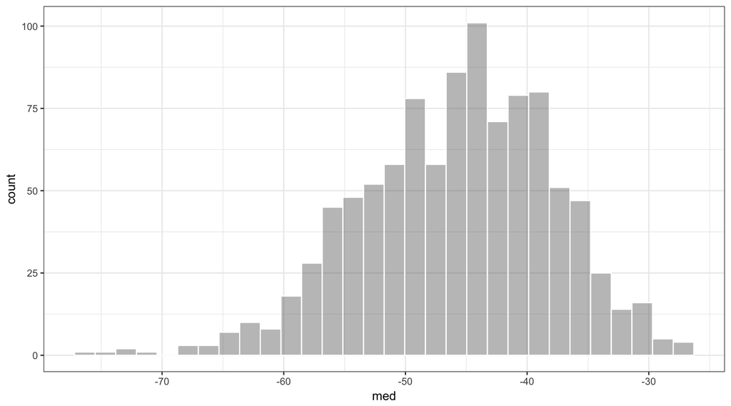

```r
summ <-
  sum %>%
  filter(time==336) %>%
  group_by(irep) %>%
  summarise(med = median(dDV))

ggplot(summ, aes( x = med)) +
  geom_histogram(alpha = 0.4, col = "white")
```

```r
summ
```

```
. # A tibble: 1,000 x 2
.     irep   med
.    <int> <dbl>
.  1     1 -55.7
.  2     2 -48.6
.  3     3 -41.6
.  4     4 -31.8
.  5     5 -44.7
.  6     6 -59.1
.  7     7 -49.6
.  8     8 -31.3
.  9     9 -35.8
. 10    10 -49.6
. # ... with 990 more rows
```

## From the abstract

> Subsequent clinical trial simulations demonstrated that a single 3.0-mg/kg SC dose of Fc-OPG would be expected to produce, at 14 days post-dose, a median NTX percentage change from baseline of −45% (with a 95% prediction interval ranging from −34% to −60%)."

```r
ans <- signif(quantile(summ$med, c(0.5,0.025,0.975)),3)

paste0(ans[1], " (", ans[3],",",ans[2],")")
```

```
. [1] "-45.1 (-31.5,-62.1)"
```

Median week-2 change from baseline with 95% interval

Probability that median cfb > 40%

```r
mean(summ$med < -40)
```

```
. [1] 0.752
```

Plot the distribution of the week-2 change from baseline

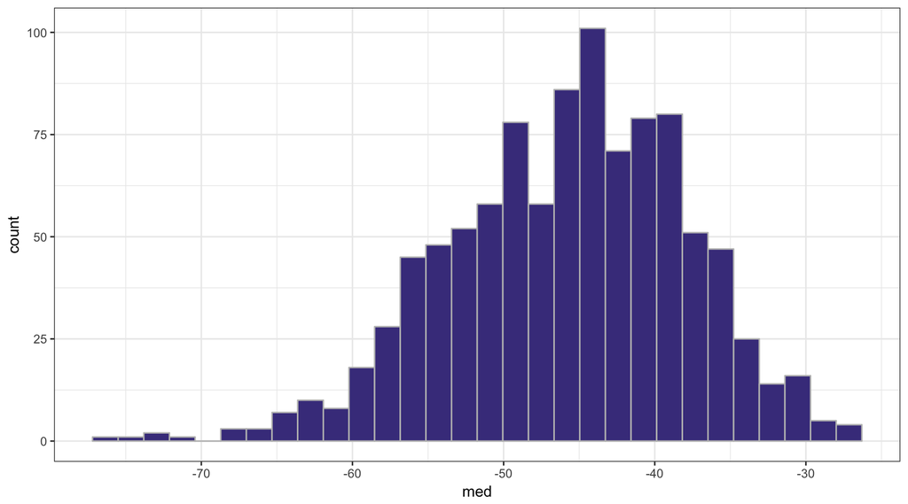

```r
ggplot(summ, aes(x=med)) +
  geom_histogram(fill="darkslateblue", col="grey")
```

# Sensitivity analysis

We are already set up to do the sensitivity analysis

```r
par <- dplyr::distinct(out,irep,TVIC50,TVQ1,TVVMAX)
head(par)
```

```
. # A tibble: 6 x 4
.    irep TVIC50  TVQ1 TVVMAX
.   <int>  <dbl> <dbl>  <dbl>
. 1     1   5.09  15.3  11890
. 2     2   3.97  14.6  13150
. 3     3   5.45  16.2  16910
. 4     4   6.17  16.1  11990
. 5     5   4.78  13.3  13420
. 6     6   3.14  13.8  12090
```

```r
sens <- left_join(summ,par)
head(sens)
```

```
. # A tibble: 6 x 5
.    irep   med TVIC50  TVQ1 TVVMAX
.   <int> <dbl>  <dbl> <dbl>  <dbl>
. 1     1 -55.7   5.09  15.3  11890
. 2     2 -48.6   3.97  14.6  13150
. 3     3 -41.6   5.45  16.2  16910
. 4     4 -31.8   6.17  16.1  11990
. 5     5 -44.7   4.78  13.3  13420
. 6     6 -59.1   3.14  13.8  12090
```

`TVIC50`

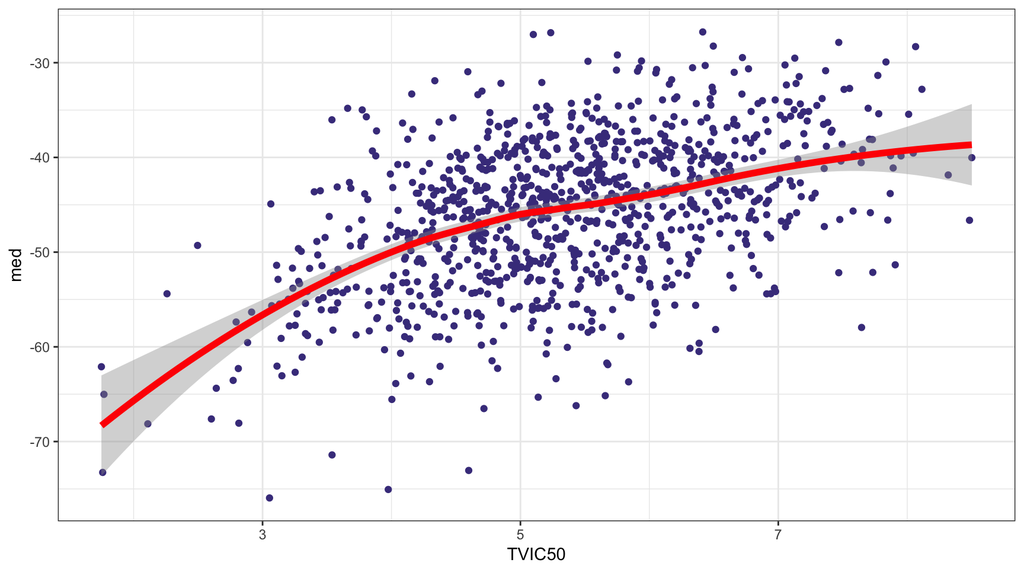

```r
ggplot(sens, aes(TVIC50, med)) +
  geom_point(col="darkslateblue") +
  geom_smooth(method="loess",col="red",lwd=2)
```

`TVVMAX`

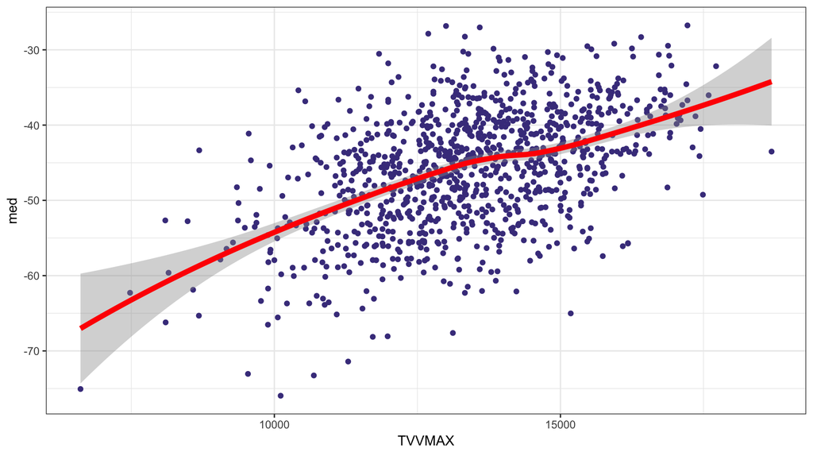

```r
ggplot(sens, aes(TVVMAX, med)) +
  geom_point(col="darkslateblue") +
  geom_smooth(method="loess",col="red",lwd=2)
```

`TVQ`

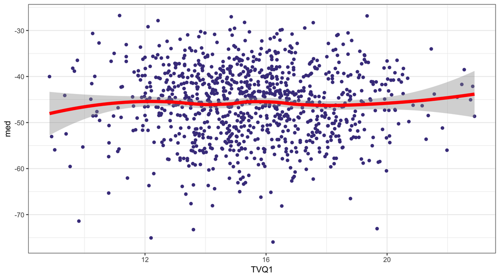

```r
ggplot(sens, aes(TVQ1, med)) +
  geom_point(col="darkslateblue") +
  geom_smooth(method="loess",col="red",lwd=2)
```